# Switching from DT

2025-01-31

Let’s say you already use `DT::datatable()` to display your data, but want to switch to `editbl::eDT()` to be able to edit it. What should you look out for?

- `eDTOutput()` uses an `id` argument instead of `outputId` since it’s actually a [shiny module](https://mastering-shiny.org/scaling-modules.html).
- `eDT()` adds extra (hidden) columns to your `datatable`. Try to format using column names instead of indexes.
- Your `datatable` now exists within a module (e.g. child namespace). This means your own chosen `outputId` is now `moduleId-DT`. This influences for example the values accessible under `input`. Example: switch from `input$outputId_cell_clicked` to `input[["moduleId-DT_cell_clicked"]]`.
- `eDT()` accepts all arguments of `DT::datatable()`, but has some different defaults for convenience.
- Any additional formatting should be done by passing a function to the `format` argument of `eDT()`.
- As always be careful when using [extensions](https://datatables.net/extensions/index) or custom javascript, not everything works well together. The [KeyTable](https://datatables.net/extensions/keytable/) and [AutoFill](https://datatables.net/extensions/autofill/) extensions of datatable are used by default and should be well integrated.

Here is an example covering the above:

```r
library(shiny)
library(DT)
library(editbl)
```

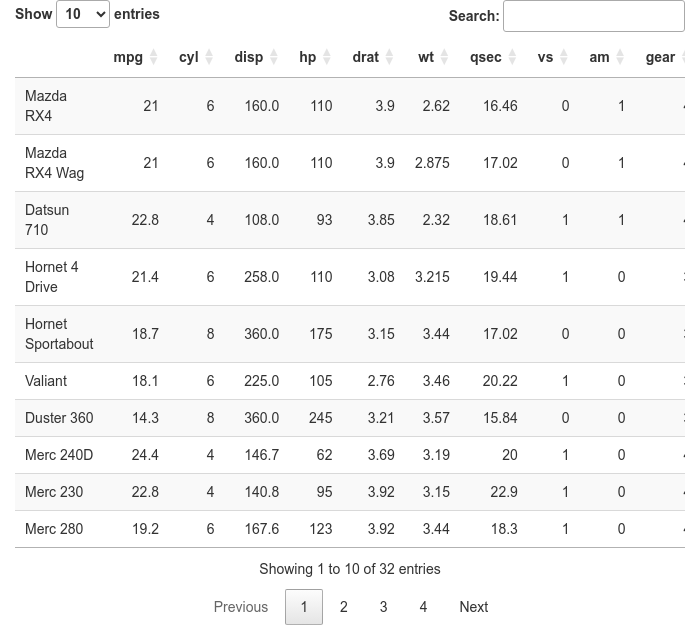

```r
ui <- fluidPage(DTOutput("DT"))
server <- function(input, output, session){
  output$DT <- renderDataTable({
    datatable(mtcars)  %>%
     formatRound('disp', 1)
  })
  observe({
      print(input[["DT_cell_clicked"]])
   })
}
shinyApp(ui, server)
```

Reworked into `eDT()`:

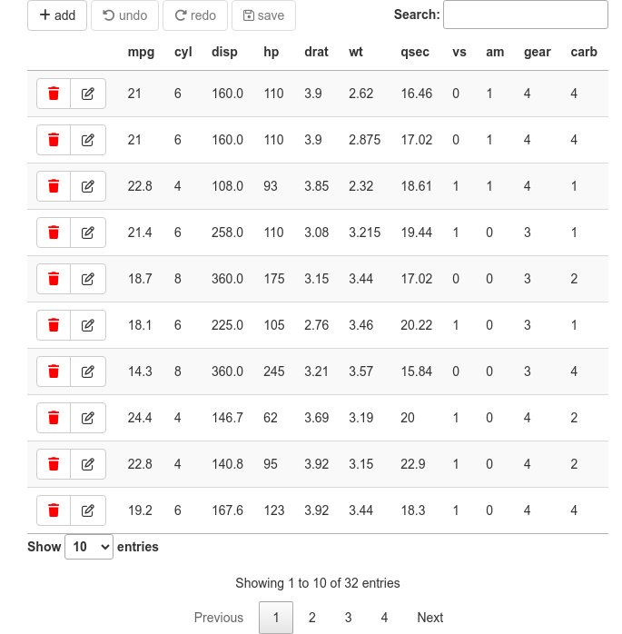

```r
ui <- fluidPage(eDTOutput("DT"))
server <- function(input, output, session){
  editbl::eDT(
    id = "DT",
    data = mtcars,
    format = function(x){formatRound(x,'disp', 1)})

   observe({
      print(input[["DT-DT_cell_clicked"]])
   })
}
shinyApp(ui, server)
```